# Andrew D. Nguyen

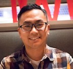

### Email: anbe642@gmail.com

### Github: adnguyen

### Website: [adnguyen.github.io](https://adnguyen.github.io/)

## Career Profile

I am a data-driven biologist with eight years of relevant experience in biostatistics in addition to five years of PhD training. I am currently a biostatistician at the Orlando Health Cancer Institute, where I lead the analyses for observational studies as well as clinical trials. My previous experiences include holding a statistical analyst position at a non-profit in the field of regulatory toxicology, and I worked for two years as a research scientist in an academic lab applying statistical techniques to understand seasonal timing in agricultural pests. The culmination of my experiences has led me to be skilled in constructing narratives from data to uncover ways to enhance patient care.

My go-to tool is R (RStudio), where I have the most experience in data wrangling (cleaning, parsing, transforming), data analysis, simulations, and data visualization.

## Experience

**2024-Present**

**Biostatistician**, [Orlando Health Cancer Institute](https://www.orlandohealth.com/services-and-specialties/orlando-health-cancer-institute/about-us), Clinical Quality Department

Serving as the lead biostatistician for clinical trials and performing critical activities such as conducting sample size calculations, drafting statistical analysis plans, and developing clinical databases (REDCap)

Supporting Clinical Quality research activities such as evaluating how different policies impact patient outcomes (survival, hospital visits, and length of stay) using causal inference techniques

**2019-2024**

**Regulatory Scientific Strategist**, [PSCI](https://www.thepsci.eu/), Regulatory Toxicology Department

Developed database and analyzed chronic toxicity studies with quantitative and qualitative approaches in collaboration with the U.S. Environmental Protection Agency (EPA) to inform risk assessments to pesticide exposure

Designed experiments, analyzed results, and submitted proposals to the US Food and Drug Administration (FDA) in support of regulatory use of in vitro methods for medical device evaluations

Consulted food and medical device companies to support safety assessments in regulatory submissions to US FDA

Communicated scientific knowledge and findings in plain English to technical and non-technical stakeholders

**2017 - 2019**

**Research Scientist**, University of Florida

Supervisor: [Dr. Daniel Hahn](http://entnemdept.ufl.edu/hahn/lab/danhahn.htm)

Managed and led an National Science Foundation funded project on the seasonal adaptation of agricultural insect pests

Investigated behavioral rhythms with time series analyses and fitting statistical models

Communicated findings in technical journals and at scientific conferences

Hosted workshops for conducting reproducible science

**2014**

**Research Associate**, [Dr. Lori Stevens lab](https://www.uvm.edu/~biology/?Page=faculty/stevens.php&SM=facultysubmenu.html); University of Vermont

Determined infection frequency of Trypanosome parasites in Kissing bugs that cause Chagas disease

Fitted statistical models for infection rates

**2010-2011**

**Technician**; [Reaction Biology Corp](http://www.reactionbiology.com/webapps/site/)

High-throughput screening of potentially therapeutic small compounds

**2009-2010**

**Technician**, Antibody Core Department; [Morphotek Inc.](http://www.morphotek.com/)

Developed therapeutic antibodies against Acute Myeloid Leukemia (AML)

Experimentally carried out bulk antibody and antigen production

**2007-2008**

**Co-op intern**, Reproductive Toxicology; [GlaxoSmithKline](http://www.gsk.com/en-gb/research/randd-locations/usa-and-canada/upper-merion/)

Studied red blood cell differentiation from mouse embryonic stem cells

Experimentally analyzed rabbit blood hormone markers

**2006-2007**

**Co-op intern**, Antibody Core Department; [Morphotek Inc.](http://www.morphotek.com/)

Developed neutralizing antibodies against Staphylococcal Enterotoxin B (SEB)

## Education

**2012-2017**

**PhD, Biology**; University of Vermont (Burlington), Department of Biology

*Thesis title: Evolutionary innovations in ants to thermally stressful environments*

Advisors: [Sara Helms Cahan](http://shelmscahan.github.io/), [Nicholas J. Gotelli](https://www.uvm.edu/~ngotelli/homepage.html)  
Committee: [Brent L. Lockwood](http://lockwoodlab.weebly.com/), [Jill Preston](https://www.uvm.edu/~plantbio/preston/Site/Home.html)

Fitted functional response curves of transcriptomic and proteomic data to understand environmental damage to whole organisms

Used machine-learning techniques to predict species presence or absence over heterogeneous climatic landscapes

Applied quantitative genetics approaches such as fitting mixed-effects models to understand gene by environmental interactions

Worked collaboratively with research groups spanning multiple universities

Communicated research findings in peer-reviewed publications, intradepartmental meetings, and national conferences

**2004-2009**

**BSc, Biology**; Drexel University (Philadelphia)

## Publications

15. Latam Collaborative Colorectal Surgery Consortium, The European Society of Coloproctology (ESCP) Global Reach Committee, **Nguyen AD**. (2026) Outcomes of urgent gastrointestinal-related procedures in Latin America (LATAM-URG): a prospective multicentre study. The Lancet Regional Health - Americas.  
14. Styrvoky K, Levine A, **Nguyen AD**, Vollenweider M, Jiwani A. (2025) Apneic oxygenation during robotic-assisted bronchoscopy: a retrospective study on safety and diagnostic yield. Journal of Thoracic Disease.  
13. Cruz Z, **Nguyen AD**, Baker S, et al. (2025) Impact of Nurse Navigation on Overall Survival and Timeliness to Care in Patients With Pancreatic Cancer in Advanced Stages. Journal of Oncology Navigation & Survivorship  
12. Chin MM, **Nguyen AD**, Jones A, et al.(2025) Electronic Health Record–Enabled Identification and Targeted Multipronged Intervention to Reduce Readmission and Length of Stay Among Patients With Metastatic Cancer. JCO Oncol Pract. doi:10.1200/OP-24-00708  
11. Petersen, E. J., **Nguyen, AD**, et al. (2021) Characteristics to consider when selecting a positive control material for an in vitro assay, ALTEX - Alternatives to animal experimentation. doi: 10.14573/altex.2102111. **Both authors contributed equally**; [Paper link](https://www.altex.org/index.php/altex/article/view/2255)  
10. **Nguyen AD** et al. 2019. Trade-Offs in Cold Resistance at the Northern Range Edge of the Common Woodland Ant Aphaenogaster picea (Formicidae). The American Naturalist. 194:6 [Paper](https://www.journals.uchicago.edu/doi/abs/10.1086/705939) and [Data](http://harvardforest.fas.harvard.edu:8080/exist/apps/datasets/showData.html?id=hf323)  
9. Powell THQ, **Nguyen AD**, et al. 2020. A rapidly evolved shift in life‐history timing during ecological speciation is driven by the transition between developmental phases. Journal of Evolutionary Biology 33:10. [Paper link](https://onlinelibrary.wiley.com/doi/abs/10.1111/jeb.13676)  
8. **Nguyen AD**, DeNovellis K, Resendez S, Pustilnik JD, Gotelli NJ, Parker JD, Cahan SH. 2017. Effects of desiccation and starvation on thermal tolerance and the heat-shock response in forest ants. J Comp Physiol B:1–10. [Paper](https://link.springer.com/article/10.1007/s00360-017-1101-x)  
7. **Nguyen AD**, Gotelli NJ, Cahan SH. 2016. The evolution of heat shock protein sequences, cis-regulatory elements, and expression profiles in the eusocial Hymenoptera. BMC Evolutionary Biology 16:15. [Paper and Data](http://bmcevolbiol.biomedcentral.com/articles/10.1186/s12862-015-0573-0)  
6. Helms Cahan S, **Nguyen AD**, Zhou Y. Population genomics supports multiple hybrid zone origins of socially hybridogenetic lineages of Pogonomyrmex harvester ants. Evolution (N Y). 2022;76(5):1016-1032. doi:10.1111/evo.14481  
5. Stevens L, Lima-Cordón RA, Helms Cahan S, **Nguyen AD**, et al. Catch me if you can: Under-detection of Trypanosoma cruzi (Kinetoplastea: Trypanosomatida) infections in Triatoma dimidiata s.l. (Hemiptera: Reduviidae) from Central America. Acta Trop. 2021;224:106130. doi:10.1016/J.ACTATROPICA.2021.106130  
4. Helms Cahan S, **Nguyen AD**, Stanton-Geddes J, Penick CA, Hernáiz-Hernández Y, DeMarco BB, Gotelli NJ. 2017. Modulation of the heat shock response is associated with acclimation to novel temperatures but not adaptation to climatic variation in the ants Aphaenogaster picea and A. rudis. Comparative Biochemistry and Physiology Part A: Molecular & Integrative Physiology 204:113–120. [Paper](http://www.sciencedirect.com/science/article/pii/S109564331630277X) and [Data](https://zenodo.org/record/164924#.WIeZtbYrJTY)  
3. Stanton-Geddes J, **Nguyen A**, Chick L, Vincent J, Vangala M, Dunn RR, Ellison AM, Sanders NJ, Gotelli NJ, Cahan SH. 2016. Thermal reactionomes reveal divergent responses to thermal extremes in warm and cool-climate ant species. BMC Genomics 17:171. [Paper and Data](http://bmcgenomics.biomedcentral.com/articles/10.1186/s12864-016-2466-z)  
2. Cicconardi F,..,**Nguyen AD**,..,Steiner FM,Schlick-Steiner, BC. 2020. Genomic signature of shifts in selection in a sub-alpine ant and its physiological adaptations. Molecular Biology and Evolution. https://doi.org/10.1093/molbev/msaa076 [Paper](https://doi.org/10.1093/molbev/msaa076)  
1. Lau MK, Ellison AM, **Nguyen A**, Penick C, DeMarco B, Gotelli NJ, Sanders NJ, Dunn RR, Helms Cahan S. 2019. Draft Aphaenogaster genomes expand our view of ant genome size variation across climate gradients. PeerJ 7:e6447 https://doi.org/10.7717/peerj.6447

## Skills

**Computing:**

- *R* – Data wrangling, visualization, and analysis within the *tidyverse*
- *Causal Inference* - Clinical trial design and target trial emulation, favoring Bayesian inference
- *Monte Carlo Simulation* - Power analyses
- *Database management* - REDCap with PowerBI integration
- *Unix* – General command line, shell bash scripting, and remote computing
- *Github* – Reproducible science through version control and online notebooks/documentation
- *Phylogenetics* - Maximum likelihood (RAxML) and Bayesian (MrBayes) methods
- Nucleotide and Protein Sequence analysis
- *Microsoft Office* – Data preparation, organization, and word processing
- Mendeley/Zotero - organize and curate references in a collaborative fashion

**Laboratory:**

- RNA,DNA, and protein isolation
- PCR and qPCR
- Gel electrophoresis: polyacrylamide and agarose
- Immunochemistry - western blots, ELISA, IHC
- Cell culture (primary and established lines)
- Flow Cytometry

## External Reviewer

Computational Toxicology  
Innate Immunity  
The Journal of Pathology  
Genome Biology and Evolution  
Molecular Ecology  
Journal of Animal Ecology  
Journal of Experimental Biology  
Scientific Reports  
Conservation Physiology  
Journal of Insect Physiology  
Insectes Sociaux  
Insect Science

## Conferences/Workshops Attended

**2023**

American Society for Cellular and Computational Toxicology ([ASCCT](https://www.ascctox.org/annual-meeting)), Silver Spring, MD

[Biocompatibility Insights](https://medicaldevice.wuxiapptec.com/events/biocompatibility-insights/), Annapolis, MD

**2022**

American Society for Cellular and Computational Toxicology ([ASCCT](https://www.ascctox.org/annual-meeting)), Gaithersburg, MD

**2020**

[Practical Methods for In Vitro Toxicology Workshop](https://iivs.org/education-outreach/practical-methods-for-in-vitro-toxicology-workshop/), Gaithersburg, MD

**2019**

[Integrating Modern Science Approaches](https://www.eiseverywhere.com/website/6947/), Houston, Texas

[Computational TOxicology: Peeking into the clouds while keeping our feet on solid ground](https://www.ascctox.org/sites/default/files/ASCCT-2019-8th-Booklet.pdf), Gaithersburg, MD

**2018**

Evolution, Montepllier, France

**2017**

Society of Integrative and Comparative Biology, New Orleans, LA

Entomological Society of America, Denver, CO

**2016**

Evolution, Austin, Texas

**2014**

Evolution, Raleigh, North Carolina

Molecular Biology and Evolution, Old San Juan, Puerto Rico

**2013**

Northeast Natural History - Ant Ecology session, Springfield, Massachusetts

**2012**

International Union for the Study of Social Insects - North American Section Meeting (IUSSI-NAS), Greensboro, North Carolina

## Organizational Membership

**2024-Present**

Florida Society of Clinical Research (FLASCO)

**2019-2024**

American Society for Cellular and Computational Toxicology (ASCCT)

**2017-2018**

Society for Reserach on Biological Rhythms (SRBR)

Entomological Society of America (ESA)

**2015-2017**

American Society of Naturalists (ASN)

**2014-2015**

Society for Integrative & Comparative Biology (SICB)

**2012-2013**

Society of Molecular Biology and Evolution (sMBE)

International Union for the Study of Social Insects (IUSSI)

Ecological Society of America (ESA)

## University Service

**2018-2019**

University Minority Mentor Program (UMMP)

- Help first year undergraduate students transition into university life.

**2018-2019**

Editor, University of Florida Postdoctoral Editors Association (UF-PEA)

- Edit written documents for language usage, puctuation, and organization.

## Outreach

**2015**

**Helper**, Software Carpentry, University of Vermont

Helped participants troubleshoot code (Unix command line, R, Github)

**2012**

**Graduate Mentor**, Ant Camp, University of Vermont

Collected ants and described their natural history with high school students